# 출력 줄인 버전

csv.reader 객체를 리스트로 만들어서  
한 3줄 정도만 출력되도록 만들었습니다

원래는 굳이 data=list(csv.reader(f)) 이렇게 리스트로 바꿀 필요 없어요

# A. 서울 기온 데이터 분석하기

1. 서울의 기온이 가장 높았던 때는 언제이고, 얼마나 더웠을까?
2. 그 밖의 질문을 만들어 해결해보자.

```python
from google.colab import drive
drive.mount('/content/drive')
```

### 0. 기상청 데이터 다운받기

기상자료개방포털(https://data.kma.go.kr)

기후통계분석 -> 기온분석 -> 검색조건별 csv 데이터 다운 (월,1904~2000,서울)

엑셀파일 열어서 필요없는 행 삭제 후 다시 csv로 저장

```python
# 구글 코랩과 구글 드라이브 연동
from google.colab import drive
drive.mount('/content/drive')
```

```python
path = '/content/drive/MyDrive/인공지능A/seoul_0400.csv'  #드라이브 내의 파일을 path변수안에 넣음.
```

### 1. 파이썬의 csv 모듈

https://docs.python.org/ko/3.10/library/csv.html#module-csv

import csv

f=open("파일명","r", encoding="인코딩")

csv.reader(f) : csv파일에서 데이터를 읽어오는 함수

csv.writer(a) : csv파일에다가 데이터를 저장하는 함수

```python
# 같은 폴더에 데이터 파일과 코드가 있는 경우(주피터노트북)

#import csv
#f=open('seoul.csv', 'r', encoding='cp949')  #파일명 직접 적어줌.
#data=csv.reader(f,delimiter=',')
```

```python
# 구글 코랩 사용할 경우

import csv
# path에 있는 csv파일을 open()함수로 열어 f에 저장, 한글 인코딩 명시
f=open(path, encoding='cp949') #파일이 path 변수 안에 있음.

#f를 reader함수를 통해 csv reader객체 data를 생성
data=list(csv.reader(f))

#data의 내용을 한줄씩 읽어서 출력함
print(data[0:3])
f.close()
```

```
[['년월', '지점', '평균기온(℃)', '최저기온(℃)', '최고기온(℃)'], ['Oct-07', '108', '13.9', '3.3', '25.4'], ['Nov-07', '108', '5.3', '-8.9', '21.3']]
```

↑ 결과는 리스트형태로, 리스트 안의 각 값은 문자열 형태로 저장되어있음

### 2. 헤더 잘라내고 데이터만 확인하기

```python
import csv
f=open(path,encoding='cp949')
data=csv.reader(f)
# header변수에 헤더 데이터행을 저장, next는 첫번째 데이터 행을 읽어오면서(딱 한 줄) 데이터의 탐색위치를 다음행으로 이동함!!
#딱 헤더(맨 첫 줄)만 똑 뗀다고 할 수 있음
header=next(data)

print(header)
f.close()
```

```
['년월', '지점', '평균기온(℃)', '최저기온(℃)', '최고기온(℃)']
```

```python
import csv
f=open(path,encoding='cp949')
data=csv.reader(f)
header=next(data)
data=list(data)
#next로 헤더 다음줄부터 시작됨
print(data[0:3])
f.close()
```

```
[['Oct-07', '108', '13.9', '3.3', '25.4'], ['Nov-07', '108', '5.3', '-8.9', '21.3'], ['Dec-07', '108', '-3.9', '-20.1', '9']]
```

### 3. 문자열을 실수형태로 변환

```python
import csv
f=open(path, encoding='cp949')
data=csv.reader(f)
header = next(data)
# 각 행의 마지막[-1] 값(최고기온)을 실수형으로 변환
for row in data:
  row[-1] = float(row[-1]) #결측값이 있어서 변환이 안 됨
f.close()
```

```
---------------------------------------------------------------------------
ValueError                                Traceback (most recent call last)
<ipython-input-13-e5ead0b7da85> in <module>()
      5 # 각 행의 마지막[-1] 값(최고기온)을 실수형으로 변환
      6 for row in data:
----> 7   row[-1] = float(row[-1]) #결측값이 있어서 변환이 안 됨
      8 f.close()

ValueError: could not convert string to float:
```

↑ 에러가 나는 이유는? -> 결측값이 있기 때문

```python
#결측값(빈칸)을 채우고 최대값 찾기
#결측값은 그냥 -999로 두고 최댓값 구하기

import csv
max_temp= -999 #최대값 비교하기 위한 초기값 (-INF)
max_data=''    # 최고기온의 날짜를 저장할 변수

f=open(path, encoding='cp949')
data=csv.reader(f)
header = next(data)

for row in data:
  if row[-1]=='': #최고기온이 없다면, 빈칸이라면,
    row[-1]=-999  # -999로 채워줌, 빈칸이었음을 표시
  row[-1] = float(row[-1])
  if max_temp < row[-1]: #최대값을 가진 날짜와 최고 기온 추출
    max_data = row[0]
    max_temp = row[-1]
f.close()
print(max_data, max_temp)
```

```
Jul-94 38.4
```

### 4. 결과를 그래프로 그리기

```
[32.9, 31.8, 33.3, 31.0, 32.2, 30.7, 35.6, 33.9, 33.2, 36.6, 36.1, 35.9, 34.3, 32.3, 34.5, 32.3, 35.4, 33.7, 33.0, 35.0, 33.7, 34.2, 35.2, 31.0, 36.3, 35.9, 31.7, 32.6, 34.3, 34.4, 34.7, 37.7, 33.9, 34.3, 36.0, 35.8, 36.0, 32.3, 36.7, 33.1, 32.9, 34.1, 36.1, 31.9, 32.8, 34.7, 31.0, 34.4, 33.6, 32.4,…
데이터갯수 :  90
```

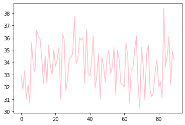

```python
import csv
import matplotlib.pyplot as plt

f=open(path, encoding='cp949')
data=csv.reader(f)
next(data)
result=[] #필요한 값을 저장해놓을 공간

for row in data:
  if row[-1] !="": #결측값은 그냥 건너뛰기
    if row[0].split('-')[0]=='Jul':                          #매년 7월의 기온만 그래프로 그려보자-'Aug'를 인식해서 result에 데이터 넣자
      result.append(float(row[-1]))
print(result)
print("데이터갯수 : ", len(result))

plt.plot(result, 'pink')
plt.show()
```

### 5. 최고기온,최저기온, 평균기온 그래프 그리기

```
[32.9, 31.8, 33.3, 31.0, 32.2, 30.7, 35.6, 33.9, 33.2, 36.6, 36.1, 35.9, 34.3, 32.3, 34.5, 32.3, 35.4, 33.7, 33.0, 35.0, 33.7, 34.2, 35.2, 31.0, 36.3, 35.9, 31.7, 32.6, 34.3, 34.4, 34.7, 37.7, 33.9, 34.3, 36.0, 35.8, 36.0, 32.3, 36.7, 33.1, 32.9, 34.1, 36.1, 31.9, 32.8, 34.7, 31.0, 34.4, 33.6, 32.4,…
[14.7, 15.4, 15.9, 16.9, 16.0, 13.0, 19.4, 15.6, 16.3, 17.7, 16.1, 16.3, 19.5, 17.4, 16.2, 16.5, 19.3, 14.5, 15.6, 18.5, 18.0, 18.4, 19.2, 15.2, 18.8, 19.1, 18.0, 17.3, 15.6, 16.6, 18.2, 17.6, 17.6, 14.6, 18.2, 17.0, 15.2, 16.0, 18.4, 17.0, 16.7, 17.0, 16.5, 13.6, 17.9, 17.5, 17.8, 19.4, 18.7, 18.6,…
[23.5, 24.6, 23.3, 23.5, 23.8, 22.3, 26.1, 25.1, 23.6, 25.7, 23.3, 25.6, 25.2, 24.0, 24.1, 24.2, 25.6, 23.3, 24.1, 25.7, 25.0, 25.9, 25.5, 22.4, 25.9, 25.5, 23.8, 23.8, 23.6, 24.6, 25.2, 27.6, 23.4, 23.7, 26.0, 26.0, 25.3, 23.2, 25.6, 22.9, 24.3, 24.8, 26.0, 21.9, 24.5, 24.3, 22.4, 25.6, 24.4, 24.8,…
데이터갯수 :  90
```

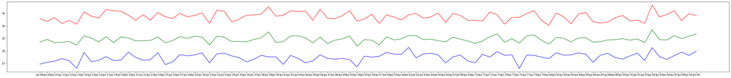

```python
import csv
import matplotlib.pyplot as plt

f=open(path, encoding='cp949')
data=csv.reader(f)
next(data)
result_h=[] #최고기온
result_m=[] #평균기온
result_l=[] #최저기온
label=[] #날짜

for row in data:
  if row[-1] !="":
    if row[0].split('-')[0]=='Jul': #매년 7월의 기온만 그래프로 그리기 위함
      result_h.append(float(row[-1])) #최고기온
      result_l.append(float(row[-2])) #최저기온
      result_m.append(float(row[-3])) #평균기온
      label.append(row[0])


print(result_h)
print(result_l)
print(result_m)
print("데이터갯수 : ", len(result_h))

plt.figure(figsize=[50,5])  #차트 크기 지정
plt.xticks(range(90),label) #X축에 라벨붙이기
plt.plot(result_h, 'red')
plt.plot(result_l, 'blue')
plt.plot(result_m, 'green')

plt.show()
```

# B. 내 생일의 기온의 변화는?

기온데이터를 일자별로 검색하여 csv파일 다운 (날짜범위는 마음대로, 지역도 마음대로)

파일 상단의 필요없는 부분 삭제하고 다른이름으로 저장

```python
path2='/content/drive/MyDrive/인공지능A/seoul_day.csv'
```

```python
import csv
f=open(path2, encoding='cp949')
data=csv.reader(f)
next(data)
data=list(data)
print(data[0:3])
```

```
[['2001-01-01', '108', '-4.5', '-9.5', '-0.8'], ['2001-01-02', '108', '-4.3', '-9.1', '-0.2'], ['2001-01-03', '108', '-8.3', '-10.4', '-5.2']]
```

```
[12.0, 13.6, 8.5, 18.7, 12.5, 6.9, 12.8, 12.0, 13.1, 3.9, 3.2, 12.9, 12.7, 18.5, 18.6, 13.8, 13.4, 12.2, 9.2, 9.1, 13.1, 16.8]
```

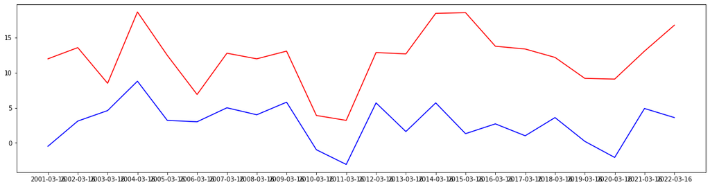

```python
# 나의 생일날짜와 같은 데이터만 추출하여 최고기온과 최저기온 그래프 그리기

import csv
import matplotlib.pyplot as plt

f=open(path2, encoding='cp949')
data=csv.reader(f)
next(data)
temp_h=[]   #최고기온
temp_l=[]   #최저기온
label2=[]   #날짜

for row in data :
  if row[-1]!="" and row[-2]!="":   #빈칸이 없을 때(결측값이 아닐 때!!)
    if row[0].split('-')[1]=="03" and row[0].split('-')[2]=="16": #월, 일 골라내기
    #내 생일 3월 16일
      temp_h.append(float(row[-1]))
      temp_l.append(float(row[-2]))
      label2.append(row[0])

print(temp_h)
plt.figure(figsize=[20,5])
plt.plot(label2, temp_h,'red')      #최고기온그래프
plt.plot(label2,temp_l,'blue')      #최저기온그래프
plt.show()
```